# Módulo 6. Análisis de componentes principales de contornos

Curso corto: Análisis de contornos de otolitos con R

Luis Cubillos

Noviembre 2026

# Objetivos del módulo

1. Elegir los armónicos con los criterios de **poder** y **varianza**.
2. Ajustar un **ACP** sobre los coeficientes de Fourier normalizados.
3. Interpretar la **varianza explicada**, los **puntajes** y las **cargas**.
4. **Reconstruir** las formas asociadas a cada componente.
5. Explorar si las **zonas** ocupan regiones distintas del morfoespacio.

```r
cf   <- read.csv("datos/coef_nef_3zonas.csv")          # módulo 5
zona <- factor(cf$zona, levels = c("Ch", "Ay", "Ma"))
coef <- as.matrix(cf[, -(1:2)])                         # A1..A25, B.., C.., D..
nh   <- 25
col_z <- c(Ch = "black", Ay = "red", Ma = "blue")
nom_z <- c(Ch = "Chiloé", Ay = "Aysén", Ma = "Magallanes")
table(zona)
```

```
#> zona
#> Ch Ay Ma
#> 26 20 21
```

# Selección de variables

# Poder y varianza acumulados (Claude 2008, p. 245)

- **Poder**: cuánto de la **forma** reconstruye cada armónico (módulo 5).
- **Varianza**: cuánto de la **variación entre individuos** contiene.

```r
power     <- rowSums(matrix(colSums(coef^2), nh, 4))
variacion <- rowSums(matrix(apply(coef, 2, var), nh, 4))
tab <- data.frame(armonico = 2:nh,
                  poder    = cumsum(power[-1]) / sum(power[-1]),
                  varianza = cumsum(variacion[-1]) / sum(variacion[-1]))
round(tab[1:13, ], 3)
```

```
#>    armonico poder varianza
#> 1         2 0.233    0.364
#> 2         3 0.919    0.569
#> 3         4 0.936    0.698
#> 4         5 0.981    0.771
#> 5         6 0.985    0.818
#> 6         7 0.993    0.857
#> 7         8 0.995    0.886
#> 8         9 0.996    0.909
#> 9        10 0.997    0.924
#> 10       11 0.998    0.938
#> 11       12 0.998    0.948
#> 12       13 0.999    0.957
#> 13       14 0.999    0.964
```

# Armónicos 2 a 12

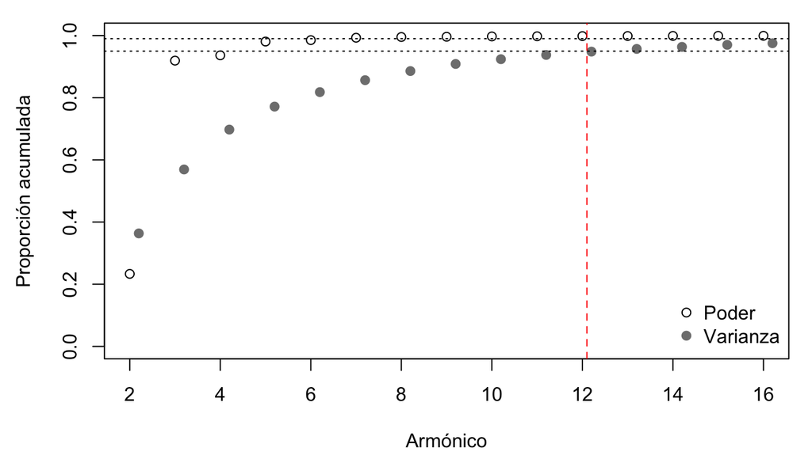

```r
par(mar = c(4.5, 4.5, 1, 1))
plot(tab$armonico[1:15], tab$poder[1:15], ylim = c(0, 1), pch = 1,
     xlab = "Armónico", ylab = "Proporción acumulada")
points(tab$armonico[1:15] + 0.2, tab$varianza[1:15], pch = 19, col = "grey50")
abline(h = c(0.95, 0.99), lty = 3); abline(v = 12.1, lty = 2, col = "red")
legend("bottomright", c("Poder", "Varianza"), pch = c(1, 19), col = c(1, "grey50"), bty = "n")
```

Se retienen los armónicos **2–12**: > 99 % del poder y ≈ 95 % de la varianza → 11 × 4 = **44 variables**.

```r
na <- 12
cols_an    <- c(2:na, nh + 2:na, 2 * nh + 2:na, 3 * nh + 2:na)   # 44 variables para el ACP
cols_forma <- c(1:na, nh + 1:na, 2 * nh + 1:na, 3 * nh + 1:na)   # 48: incluye el 1er armónico
X <- coef[, cols_an]
dim(X)
```

```
#> [1] 67 44
```

# Análisis de componentes principales

# ¿Qué hace el ACP?

- Rota los ejes para que el 1º (**PC1**) siga la dirección de **máxima varianza**, el 2º la máxima varianza restante y perpendicular al 1º, etc.
- Resume muchas variables correlacionadas en pocos ejes **no correlacionados**.
- **No usa los grupos**: es una exploración de la variación de forma de toda la muestra.

Los coeficientes de Fourier normalizados están en las **mismas unidades**: se usa la matriz de **covarianza** (sin estandarizar), como en Claude (2008). Estandarizar daría el mismo peso al ruido de los armónicos altos que a la forma general.

# Ajuste con `princomp()`

```r
pc <- princomp(X)                    # matriz de covarianza
var_pc <- pc$sdev^2 / sum(pc$sdev^2)
round(rbind(proporcion = var_pc[1:6], acumulada = cumsum(var_pc)[1:6]), 3)
```

```
#>            Comp.1 Comp.2 Comp.3 Comp.4 Comp.5 Comp.6
#> proporcion  0.248  0.217  0.129  0.083  0.060  0.045
#> acumulada   0.248  0.465  0.594  0.677  0.737  0.782
```

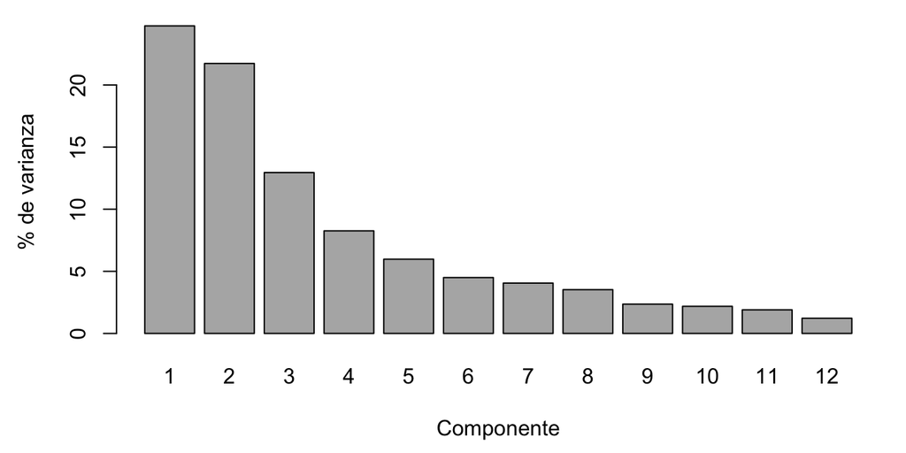

```r
par(mar = c(4.5, 4.5, 1, 1))
barplot(100 * var_pc[1:12], names.arg = 1:12, col = "grey70",
        xlab = "Componente", ylab = "% de varianza")
```

`prcomp(X)` da el mismo resultado (usa SVD; signos de los ejes pueden diferir).

# Plano PC1–PC2

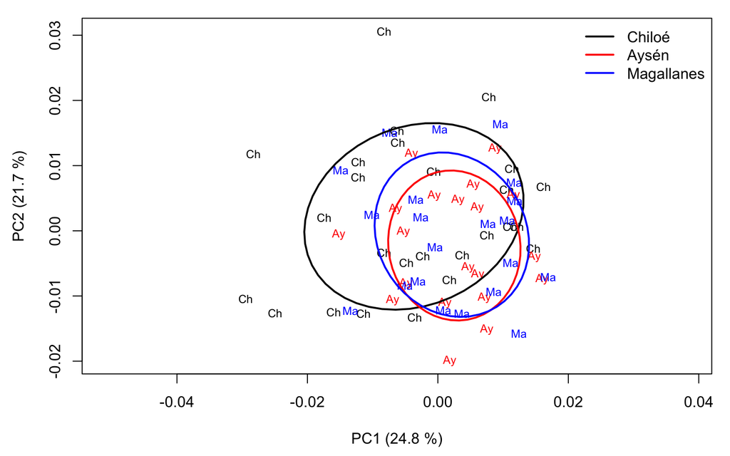

```r
sc <- pc$scores
par(mar = c(4.5, 4.5, 1, 1))
plot(sc[, 1:2], type = "n", asp = 1,
     xlab = sprintf("PC1 (%.1f %%)", 100 * var_pc[1]),
     ylab = sprintf("PC2 (%.1f %%)", 100 * var_pc[2]))
text(sc[, 1], sc[, 2], as.character(zona), col = col_z[zona], cex = 0.75)
for (z in levels(zona))
  lines(elipse(sc[zona == z, 1], sc[zona == z, 2], conf = 0.8), col = col_z[z], lwd = 2)
legend("topright", nom_z, col = col_z, lwd = 2, bty = "n")
```

Elipses de confianza (80 %) con `elipse()`: las zonas se **superponen** mucho.

# Cargas: ¿qué armónicos pesan en cada eje?

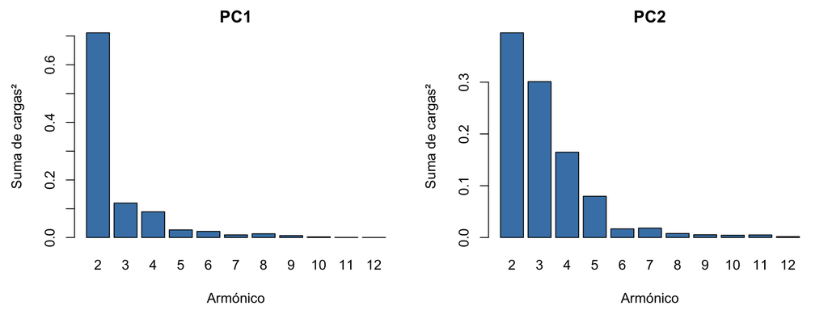

```r
ev <- unclass(pc$loadings)                    # vectores propios (44 x 44)
arm <- rep(2:na, 4)                            # armónico de cada variable
par(mfrow = c(1, 2), mar = c(4.5, 4.5, 2, 1))
for (j in 1:2)
  barplot(tapply(ev[, j]^2, arm, sum), col = "steelblue", main = paste0("PC", j),
          xlab = "Armónico", ylab = "Suma de cargas²")
```

Los primeros componentes están dominados por los **armónicos bajos** (forma general); los altos (detalle fino) aportan poco.

# Reconstrucción de formas

# Del eje a la forma (Claude 2008, pp. 246–247)

1. Calcular los coeficientes de la **forma media**, *incluido* el 1er armónico.
2. Sumar a la media el **puntaje extremo × vector propio** del eje.
3. Como el ACP se hizo **sin** el 1er armónico, insertar un **0** en esa posición de cada bloque A, B, C, D.
4. Reconstruir el contorno con `iefourier()`.

```r
forma_media <- colMeans(coef[, cols_forma])          # 48 coeficientes
expandir <- function(v) {                             # 44 cargas -> 48 (0 en el 1er armónico)
  m <- na - 1
  c(0, v[1:m], 0, v[m + 1:m], 0, v[2 * m + 1:m], 0, v[3 * m + 1:m])
}
reconstruir <- function(cf, k = na, n = 100) {        # 48 coeficientes -> contorno
  r <- iefourier(cf[1:na], cf[na + 1:na], cf[2 * na + 1:na], cf[3 * na + 1:na], k, n)
  list(x = c(r$x, r$x[1]), y = c(r$y, r$y[1]))
}
```

# Formas extremas en PC1 y PC2

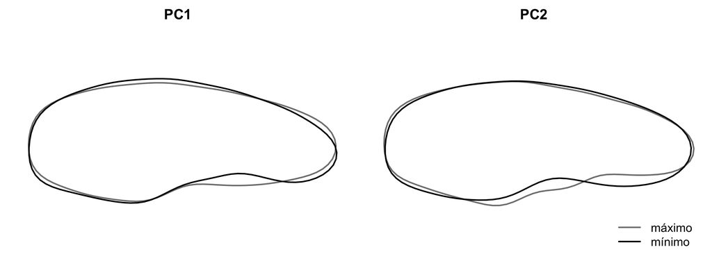

```r
par(mfrow = c(1, 2), mar = c(1, 1, 2, 1))
for (j in 1:2) {
  Mx <- reconstruir(forma_media + max(sc[, j]) * expandir(ev[, j]))
  mx <- reconstruir(forma_media + min(sc[, j]) * expandir(ev[, j]))
  plot(Mx, type = "l", asp = 1, axes = FALSE, xlab = "", ylab = "", lwd = 2,
       col = "grey50", main = paste0("PC", j), xlim = c(-1.1, 1.1), ylim = c(-0.6, 0.6))
  lines(mx, lwd = 2)
}
legend("bottomright", c("máximo", "mínimo"), col = c("grey50", "black"), lwd = 2, bty = "n")
```

# Formas a lo largo de cada eje

Formas teóricas a −2, −1, 0, +1 y +2 desviaciones estándar del componente:

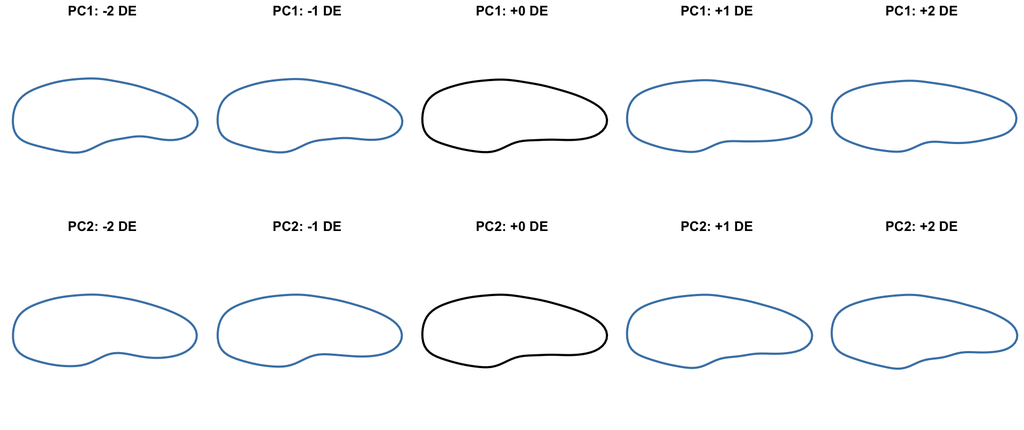

```r
par(mfrow = c(2, 5), mar = c(0.3, 0.3, 1.6, 0.3))
for (j in 1:2) for (s in -2:2) {
  f <- reconstruir(forma_media + s * pc$sdev[j] * expandir(ev[, j]))
  plot(f, type = "l", asp = 1, axes = FALSE, xlab = "", ylab = "", lwd = 2,
       xlim = c(-1.1, 1.1), ylim = c(-0.6, 0.6),
       col = if (s == 0) "black" else "steelblue", main = sprintf("PC%d: %+d DE", j, s))
}
```

# Morfoespacio

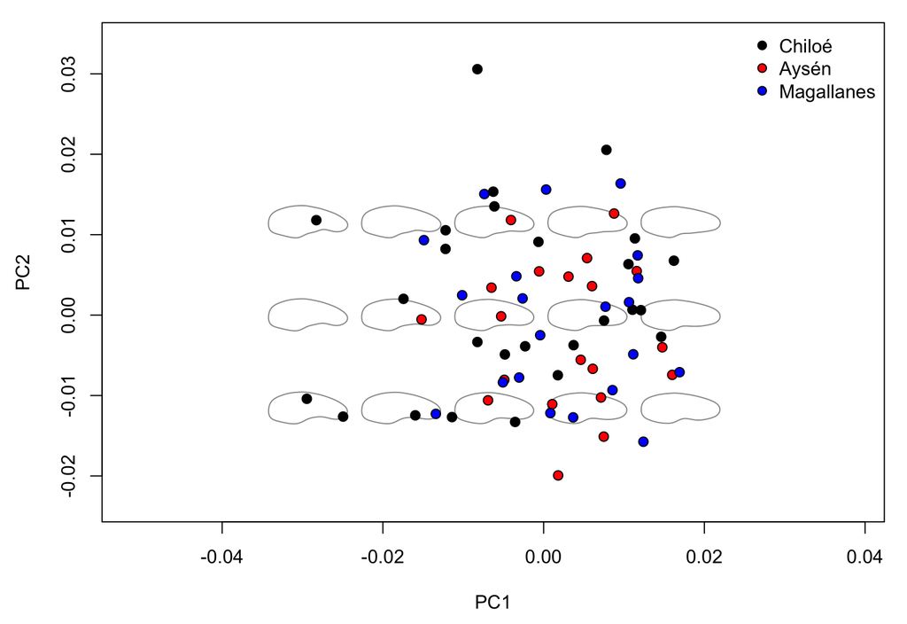

```r
par(mar = c(4.5, 4.5, 1, 1))
paso <- diff(range(sc[, 1])) / 4                    # misma separación en ambos ejes
gx <- seq(min(sc[, 1]), max(sc[, 1]), by = paso)
gy <- seq(mean(sc[, 2]) - paso, mean(sc[, 2]) + paso, by = paso)
plot(sc[, 1:2], type = "n", asp = 1, xlab = "PC1", ylab = "PC2",
     xlim = range(gx) + c(-0.5, 0.5) * paso, ylim = range(gy, sc[, 2]) + c(-0.3, 0.3) * paso)
esc <- 0.38 * paso                                  # tamaño de los contornos en el gráfico
for (a in gx) for (b in gy) {
  f <- reconstruir(forma_media + a * expandir(ev[, 1]) + b * expandir(ev[, 2]))
  lines(a + esc * f$x, b + esc * f$y, col = "grey60")
}
points(sc[, 1:2], pch = 21, bg = col_z[zona], cex = 1.1)
legend("topright", nom_z, pt.bg = col_z, pch = 21, bty = "n")
```

Cada contorno gris es la forma **teórica** en ese punto del plano PC1–PC2.

# Interpretación

# Puntajes por zona

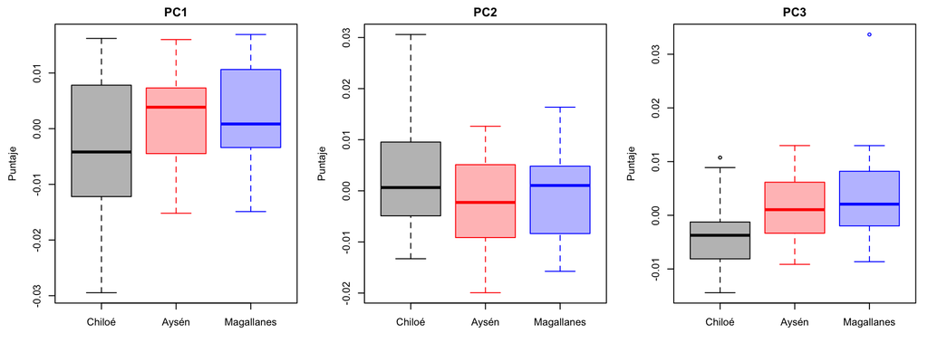

```r
par(mfrow = c(1, 3), mar = c(4, 4.5, 2, 1))
for (j in 1:3)
  boxplot(sc[, j] ~ zona, col = adjustcolor(col_z, 0.3), border = col_z,
          names = nom_z, main = paste0("PC", j), ylab = "Puntaje", xlab = "")
```

```r
sapply(1:3, function(j) summary(aov(sc[, j] ~ zona))[[1]][["Pr(>F)"]][1])   # valor p por eje
```

```
#> [1] 0.08630595 0.32413630 0.00193623
```

# Cuidados al interpretar el ACP

- El ACP **describe** la variación total; **no** maximiza la separación entre grupos. Que las zonas se superpongan en PC1–PC2 no implica que no difieran.
- Para **probar** diferencias y **clasificar**: MANOVA/PERMANOVA y análisis discriminante (Claude 2008, secc. 6.2), sobre los coeficientes o sobre los primeros componentes.
- Con 44 variables y 20–26 otolitos por zona, las variables se acercan al número de observaciones: conviene trabajar con **pocos componentes** o pocos armónicos.
- La forma puede cambiar con la **talla** y la **edad**: si las zonas difieren en talla, parte de la diferencia de forma puede ser **alometría**.
- Revisar **puntos extremos** en el plano PC: suelen ser otolitos dañados o mal digitalizados (módulos 3 y 4).

# Exportar resultados

```r
res_pc <- data.frame(id = cf$id, zona = zona, round(sc[, 1:5], 5))
write.csv(res_pc, "datos/puntajes_acp.csv", row.names = FALSE)
write.csv(round(ev[, 1:5], 5), "datos/cargas_acp.csv")
head(res_pc, 3)
```

```
#>     id zona   Comp.1   Comp.2   Comp.3   Comp.4   Comp.5
#> 1 Ch01   Ch  0.01211  0.00062 -0.00076  0.01195  0.01033
#> 2 Ch02   Ch -0.02828  0.01181 -0.00378 -0.00505 -0.00698
#> 3 Ch03   Ch -0.00230 -0.00388 -0.00973 -0.00793  0.00628
```

# Resumen del curso

**Imagen** → binarización → `Conte()` → **pseudolandmarks** → **CSV/XLSX** → `efourier()` / `NEF()` → armónicos 2–12 → **ACP** → formas reconstruidas

| Módulo | Funciones clave |
| --- | --- |
| 2 | `read.pnm()`, `binarizar()`, `Conte()` |
| 3 | `seq()`, `equiespaciar()`, `regularradius()` |
| 4 | `read.csv()`, `write.csv()`, `read_excel()`, `write_xlsx()`, `largo_a_array()` |
| 5 | `efourier()`, `iefourier()`, `NEF()` |
| 6 | `princomp()`, `elipse()`, `reconstruir()` |

# Ejercicio final

1. Repita el ACP con los armónicos **2–8**. ¿Cambia la varianza explicada por PC1 y la interpretación de las formas extremas?
2. Agregue **D1** (elongación de la 1ª elipse) a las variables. ¿Qué componente la captura?
3. Proyecte el otolito de sardina común (módulo 3) en el ACP con `predict(pc, nuevos_coeficientes)`. ¿Dónde cae respecto de la merluza de cola?
4. Haga el ACP con `prcomp(X)` y compare los puntajes con los de `princomp()`.

# Referencias

- **Claude, J. (2008). *Morphometrics with R*. Springer.** Secc. 6.1.2 y fe de erratas v1.8.
- Cadrin, S.X., Friedland, K.D. y Waldman, J.R. (eds.) (2005). *Stock Identification Methods*. Elsevier.
- Campana, S.E. y Casselman, J.M. (1993). *Can. J. Fish. Aquat. Sci.* 50: 1062–1083.
- Ferson, S., Rohlf, F.J. y Koehn, R.K. (1985). *Syst. Zool.* 34: 59–68.
- Kuhl, F.P. y Giardina, C.R. (1982). *Comput. Graph. Image Process.* 18: 236–258.